# TubesFSD_18523160_18523252 Prediksi Ketepatan Kelulusan Mahasiswa Berdasarkan IP

Salsabila, Nabilah Nuur Ainii

12/19/2020

```r
library('caret')
```

```r
library('ggplot2')
library('e1071')
```

Package caret sangat membantu karena package ini menyediakan akses langsung ke berbagai macam fungsi untuk mentraining model kita dengan berbagai macam variasi algoritma machine learning seperti SVM, KNN, pohon keputusan, regresi linear, dan lain lain. Package ggplot2 adalah package yang sangat membantu dalam hal memvisualisasikan data yang ada seperti ploting data.

```r
data<- read.csv('/Users/nabilahnran/Downloads/data_lulus_tepat_waktu.csv')
```

Kami akan memprediksi ketepatan kelulusan kuliah dengan memakai metode SVM (Support Vector Machine) dengan memakai sebuah dataset dari Kaggle berjudul ‘On Time Graduation Classification’ (https://www.kaggle.com/oddyvirgantara/on-time-graduation-classification). Disini dataset kami masukan ke variabel ‘data’

```r
data
```

```
##       ip1  ip2  ip3  ip4 tepat
## 1    2.30 1.97 1.80 1.56 Tidak
## 2    1.81 1.68 1.57 1.86 Tidak
## 3    3.07 3.00 2.75 3.21 Tidak
## 4    2.71 2.33 2.61 1.98 Tidak
## 5    3.17 3.02 3.28 2.96 Tidak
## 6    3.16 3.45 3.02 3.06 Tidak
## 7    2.72 2.50 2.92 3.00 Tidak
## 8    2.97 3.27 2.90 2.83 Tidak
## 9    2.72 2.61 2.64 2.46 Tidak
## 10   2.78 2.85 3.08 3.35 Tidak
## 11   2.50 1.56 3.17 3.33 Tidak
## 12   2.19 2.92 2.54 2.67 Tidak
## 13   3.43 3.18 3.41 3.45    Ya
## 14   3.14 2.75 3.01 3.38 Tidak
```

[output cut: 1673 more lines]

Dataset ini memiliki 4 fitur yaitu IP semester 1, IP semester2, IP semester 3, dan IP semester 4. Data ini juga memiliki 2 kelas yaitu kelas Ya dan Tidak dalam hal ketepatan kelulusan. kami akan menggunakan variabel tepat untuk memprediksi.

```r
nrow(data)
```

```
## [1] 1687
```

Dataset ini memilik data sebanyak 1687, dihitung dari barisnya.

```r
str(data)
```

```
## 'data.frame':    1687 obs. of  5 variables:
##  $ ip1  : num  2.3 1.81 3.07 2.71 3.17 3.16 2.72 2.97 2.72 2.78 ...
##  $ ip2  : num  1.97 1.68 3 2.33 3.02 3.45 2.5 3.27 2.61 2.85 ...
##  $ ip3  : num  1.8 1.57 2.75 2.61 3.28 3.02 2.92 2.9 2.64 3.08 ...
##  $ ip4  : num  1.56 1.86 3.21 1.98 2.96 3.06 3 2.83 2.46 3.35 ...
##  $ tepat: chr  "Tidak" "Tidak" "Tidak" "Tidak" ...
```

```r
summary(data)
```

```
##       ip1             ip2             ip3            ip4
##  Min.   :0.830   Min.   :0.230   Min.   :0.55   Min.   :0.900
##  1st Qu.:3.020   1st Qu.:3.060   1st Qu.:3.12   1st Qu.:3.170
##  Median :3.220   Median :3.270   Median :3.31   Median :3.390
##  Mean   :3.174   Mean   :3.171   Mean   :3.25   Mean   :3.286
##  3rd Qu.:3.405   3rd Qu.:3.440   3rd Qu.:3.46   3rd Qu.:3.520
##  Max.   :3.860   Max.   :4.000   Max.   :3.92   Max.   :3.910
##     tepat
##  Length:1687
##  Class :character
##  Mode  :character
##
##
##
```

```r
anyNA(data)
```

```
## [1] FALSE
```

dengan fungsi ini kita akan mengecek apakah ada data null pada data kami. Hasilnya adalah FALSE, artinya tidak ada data yang bernilai null atau missing values pada data ‘data’.

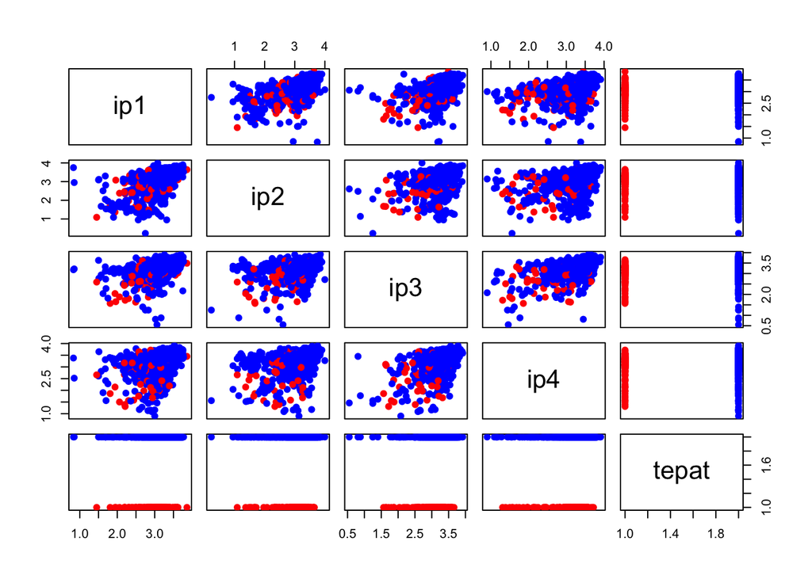

```r
plot(data,col = ifelse(data$tepat=="Ya", "blue", "red"), pch=19)
```

Dataset diplot per baris x kolom. karena dataset memiliki 5 kolom, maka akan tertampil sebanyak 25 plot (baris 1 kolom 2 adalah plot dari variabel ip1 dan ip2, begitu seterusnya hingga baris 5 kolom 4 yaitu plot dari variabel ip4 dengan ketepatan kelulusan). Data berwarna biru adalah data angka yang memiliki kelas tepat waktu (Ya), dan berwarna merah adalah data yang memiliki kelas tidak tepat waktu (Tidak). Terlihat bahwa data yang memiliki kelas ‘Ya’ memiliki jumlah yang lebih dominan dibandingkan kelas ‘Tidak’. Dalam persebarannya, data terlampau tercampur secara acak pada plot antara fitur, sedangkan plot antara fitur dan kelas terbagi menjadi 2 bagian karena terbagi hanya pada 2 kelas.

```r
table(data$tepat)
```

```
##
## Tidak    Ya
##   135  1552
```

Untuk frekuensi pada kelas ‘Ya’ dan ‘Tidak’, terlihat bahwa jumlah data pada dua kelas tersebut selisihnya sangat jauh, perbedaannya hampir 1:12. Sama seperti pada plot sebelumnya dimana data berwarna biru lebih dominan daripada data berwarna merah.

```r
library('ROSE')
```

Oleh karena itu, kami melakukan resampling guna merubah frekuensinya. disini kami menginstall package ROSE untuk memakai fungsi ovun.sample yang berfungsi untuk meresampling data.

```r
data_balanced<- ovun.sample(tepat ~ ., data = data, method = "over",N = 3104)$data
table(data_balanced$tepat)
```

```
##
## Tidak    Ya
##  1552  1552
```

Pada resampling ini kami menggunakan metode random oversampling dimana metode ini akan menduplikasi data yang ada di kelas minoritas sehingga frekuensinya naik. Dengan fungsi ovun.sample, kami meresapling fitur tepat, dari data awal bernama data, dengan mengisi method dengan ‘over’ untuk oversampling, dan variabel N untuk jumlah observasi dalam hasil data yang seimbang. Pada data awal, kami memiliki jumlah 1552 pada data ‘Ya’ yang mayoritas, maka kami memberikan instruksi untuk oversample kelas minoritas sampai dia mencapai 1552 yang jumlahnya menjadi setara, maka nilai N kami isi dengan 1552 x 2 yaitu 3104. Maka hasilnya dapat dilihat jumlah data pada kedua kelas sudah sama, 1552. Data yang sudah di resampling ini kemudian dimasukkan didalam variabel data_balannced yang kemudian akan dipakai untuk langkah langkah selanjutnya.

```r
write.csv(data_balanced,'data_balanced.csv')
dataa<- read.csv('/Users/nabilahnran/Documents/KULYEAH/TUGAS DAN MATERI/SMT 5/FSD/data_balanced.csv')
dataa
```

```
##         X  ip1  ip2  ip3  ip4 tepat
## 1       1 3.43 3.18 3.41 3.45    Ya
## 2       2 3.04 2.95 3.14 2.98    Ya
## 3       3 2.83 2.56 3.00 2.79    Ya
## 4       4 2.60 2.72 3.08 2.54    Ya
## 5       5 2.98 3.02 2.98 2.90    Ya
## 6       6 3.10 3.34 3.38 3.42    Ya
## 7       7 2.52 2.36 1.85 2.73    Ya
## 8       8 3.17 3.50 3.46 3.58    Ya
## 9       9 3.06 3.21 3.23 3.35    Ya
## 10     10 2.92 1.78 3.21 3.04    Ya
## 11     11 3.00 1.50 3.23 3.15    Ya
## 12     12 3.10 3.39 3.17 3.08    Ya
## 13     13 2.84 3.02 3.21 2.83    Ya
## 14     14 3.02 2.97 3.04 3.04    Ya
```

[output cut: 3090 more lines]

disini kami memasukkan data yang sudah di resampling ke csv baru agar nilainya tidak berubah rubah.

```r
dataa <- dataa[,-1]
dataa
```

```
##       ip1  ip2  ip3  ip4 tepat
## 1    3.43 3.18 3.41 3.45    Ya
## 2    3.04 2.95 3.14 2.98    Ya
## 3    2.83 2.56 3.00 2.79    Ya
## 4    2.60 2.72 3.08 2.54    Ya
## 5    2.98 3.02 2.98 2.90    Ya
## 6    3.10 3.34 3.38 3.42    Ya
## 7    2.52 2.36 1.85 2.73    Ya
## 8    3.17 3.50 3.46 3.58    Ya
## 9    3.06 3.21 3.23 3.35    Ya
## 10   2.92 1.78 3.21 3.04    Ya
## 11   3.00 1.50 3.23 3.15    Ya
## 12   3.10 3.39 3.17 3.08    Ya
## 13   2.84 3.02 3.21 2.83    Ya
## 14   3.02 2.97 3.04 3.04    Ya
```

[output cut: 3090 more lines]

disini kolom 1 pada dataset dataa dihapus karena merupakan kolom yg otomatis ditambah setelah resampling, kami hapus karena mungkin dapat merubah hasil training maupun test.

```r
intrain <- createDataPartition(y = dataa$tepat, p= 0.8, list = FALSE)
```

```r
training <- dataa[intrain,]
```

variabel training yang akan kita gunakan untuk menampung data yang akan digunakan untuk training, diisi dengan data yang telah dimasukkan ke variabel intrain yang mana berjumlah 80% dari data pada dataset dataa.

```r
testing <- dataa[-intrain,]
```

variabel testing yang akan kita gunakan untuk menampung data yang akan digunakan untuk testing, diisi dengan data selain data yang dimasukkan ke variabel intrain, yang mana berjumlah 20% dari data pada dataset dataa.

```r
dim(training)
```

```
## [1] 2484    5
```

dimensi dari data training (80% dari data_ awal_balanced), yaitu 2484 row dan 5 column.

```r
dim(testing)
```

```
## [1] 620   5
```

dimensi dari data testing (20% dari data_balanced), yaitu 620 row dan 5 column.

```r
training[["tepat"]] = factor(training[["tepat"]])
```

karena kolom ‘tepat’ yang akan dijadikan target, code diatas dapat merubah training data frame kolom ‘tepat’ menjadi variabel faktor.

```r
trctrl <- trainControl(method = "repeatedcv", number = 10, repeats = 3)
```

Method trainControl() akan mengontrol semua komputasi overhead sehingga kita dapat memakai fungsi train() yang disediakan oleh package caret. training method akan melatih data kami pada alogoritma yang berbeda beda. hasil dari metod ini akan kami simpan pada variabel trctrl. Parameter ‘method’ menentukan method apa yang dipakai untuk resampling, kami menggunakan salah satu method cross validation. Langkah ini merupakan salah satu metode cross validation yaitu dengan repeated K-fold cross validation yang diulang beberapa kali. Parameter ‘number’ yang menetapkan jumlah perulangan resamplingnya. Parameter ‘reapeats’ berisi jumlah set untuk repeated cross validation kami. Method trainControl ini akan mengembalikan sebuah list. kami akan passing list ini ke method train().

```r
svm_Linear <- train(tepat ~., data = training, method = "svmLinear",
                    trControl=trctrl,
                    preProcess = c("center", "scale"),
                    tuneLength = 10);
```

Method train() disimpan dengan parameter method ‘svmLinear’ karena kami menggunakan metode SVM. kami mengirim variabel target ‘tepat’. ‘tepat~.’ menunjukkan sebuah formula untuk memakai semua atribut yang ada pada classifier dan variabel tepat sebagai variabel target. Parameter ‘data’ menentukan data mana yang akan dipakai untuk training, disini kami memakai data training yang sudah dimasukkan ke variabel training sebelumnya. Parameter trCrntrol mendapatkan hasil dari method trainControl() sebelumnya dengan mengambil variabel trctrl. Parameter ‘preProcess’ untuk preprocessing data training kami. kami menempatkan 2 value pada parameter preProcess yaitu ‘center’ dan ‘scale’, dua value ini membantu untuk memusatkan dan mengatur skala data Setelah preprocessing, fungsi ini menkonversi data training dengan nilai mean 0 dan standar deviasi 1. Parameter ‘tuneLength’ yang berisi integer dipakai untuk mengontrol jumlah kombinasi.

```r
svm_Linear
```

```
## Support Vector Machines with Linear Kernel
##
## 2484 samples
##    4 predictor
##    2 classes: 'Tidak', 'Ya'
##
## Pre-processing: centered (4), scaled (4)
## Resampling: Cross-Validated (10 fold, repeated 3 times)
## Summary of sample sizes: 2236, 2235, 2236, 2235, 2235, 2235, ...
## Resampling results:
##
##   Accuracy   Kappa
##   0.6431929  0.2863887
##
## Tuning parameter 'C' was held constant at a value of 1
```

Hasil dari metode train(). Ini adalah model linear yang dilatih dengan value C = 1. C atau Cost adalah sebuah nilai yang digunakan untuk mengontrol tingkat kesalahan klasifikasi pada data yang dilatih. Semakin besar nilai cost, semakin kecil kesalahan klasifikasi. Pada hasil diatas, hasil cost kecil. dari 2484 sampel, model ini sesuai dengan kasus yang akan dipredict.

```r
test_pred <- predict(svm_Linear, newdata = testing)
```

Setelah training, sekarang data test siap untuk di prediksi. package caret menyiapkan method predict() untuk memprediksi hasil. Parameter pertama adalah model yang telah dilatih, dan parameter kedua adalah parameter ‘newdata’ yang diisi dengandata frame testing, yang sudah dimasukan sebelumnya dalam variabel testing. Method predict() mengembalikan sebuah list, yang kami simpan dalam variabel test_pred.

```r
test_pred
```

```
##   [1] Ya    Tidak Ya    Ya    Tidak Tidak Tidak Ya    Ya    Ya    Tidak Tidak
##  [13] Tidak Ya    Tidak Tidak Tidak Ya    Ya    Tidak Tidak Tidak Ya    Ya
##  [25] Ya    Tidak Tidak Tidak Ya    Ya    Ya    Ya    Tidak Tidak Ya    Tidak
##  [37] Ya    Ya    Ya    Tidak Tidak Tidak Tidak Tidak Tidak Tidak Ya    Ya
##  [49] Ya    Ya    Ya    Ya    Ya    Ya    Tidak Tidak Tidak Ya    Ya    Ya
##  [61] Tidak Tidak Tidak Tidak Tidak Tidak Tidak Tidak Tidak Ya    Ya    Tidak
##  [73] Tidak Tidak Tidak Tidak Tidak Tidak Tidak Ya    Ya    Ya    Ya    Tidak
##  [85] Ya    Tidak Ya    Ya    Ya    Ya    Tidak Ya    Ya    Tidak Tidak Ya
##  [97] Tidak Tidak Ya    Ya    Ya    Ya    Ya    Ya    Ya    Ya    Ya    Ya
## [109] Tidak Tidak Ya    Ya    Ya    Tidak Ya    Ya    Ya    Tidak Ya    Ya
## [121] Ya    Tidak Tidak Ya    Ya    Ya    Ya    Ya    Ya    Ya    Ya    Ya
## [133] Ya    Ya    Ya    Ya    Ya    Ya    Ya    Ya    Ya    Ya    Ya    Ya
## [145] Ya    Ya    Ya    Ya    Ya    Ya    Ya    Ya    Ya    Tidak Tidak Ya
## [157] Ya    Ya    Ya    Ya    Ya    Ya    Ya    Tidak Ya    Ya    Ya    Ya
## [169] Ya    Ya    Ya    Ya    Ya    Tidak Ya    Ya    Ya    Ya    Tidak Ya
```

[output cut: 38 more lines]

```r
confusionMatrix(table(test_pred, testing$tepat))
```

```
## Confusion Matrix and Statistics
##
##
## test_pred Tidak  Ya
##     Tidak   144  73
##     Ya      166 237
##
##                Accuracy : 0.6145
##                  95% CI : (0.5749, 0.653)
##     No Information Rate : 0.5
##     P-Value [Acc > NIR] : 6.472e-09
##
##                   Kappa : 0.229
##
##  Mcnemar's Test P-Value : 2.665e-09
##
##             Sensitivity : 0.4645
##             Specificity : 0.7645
##          Pos Pred Value : 0.6636
##          Neg Pred Value : 0.5881
##              Prevalence : 0.5000
##          Detection Rate : 0.2323
##    Detection Prevalence : 0.3500
##       Balanced Accuracy : 0.6145
##
##        'Positive' Class : Tidak
##
```

Outputnya menunjukkan bahwa dimana jumlah akurasinya tidak terlalu tinggi dilihat juga dari matriks jumlah data test_pred di bagian atas. Dengan urutan yang sama dengan sebelumnya, kami juga akan membuat model svmLinear Classifier.

```r
grid <- expand.grid(C = c(0,0.01, 0.05, 0.1, 0.25, 0.5, 0.75, 1, 1.25, 1.5, 1.75, 2,5))
svm_Linear_Grid <- train(tepat ~., data = training, method = "svmLinear",
                         trControl=trctrl,
                         preProcess = c("center", "scale"),
                         tuneGrid = grid,
                         tuneLength = 10)
```

Kami melakukan customization untuk memilih value C (cost) di linear classifier. Ini dilakukan dengan memasukkan nilai di grid. Disini kami membuat dan mengatur sebuah SVM classifier dengan nilai cost yang berbeda beda. Kami menempatkan beberapa nilai C menggunakan fungsi expand.grid() kedalam dataframe grid. Selanjutnya, datafarame ini digunakan untuk mengetes classifier pada nilai C yang spesifik dengan menggunakan method train() dengan parameter tuneGrid.

```r
svm_Linear_Grid
```

```
## Support Vector Machines with Linear Kernel
##
## 2484 samples
##    4 predictor
##    2 classes: 'Tidak', 'Ya'
##
## Pre-processing: centered (4), scaled (4)
## Resampling: Cross-Validated (10 fold, repeated 3 times)
## Summary of sample sizes: 2235, 2235, 2236, 2236, 2236, 2236, ...
## Resampling results across tuning parameters:
##
##   C     Accuracy   Kappa
##   0.00        NaN        NaN
##   0.01  0.6390368  0.2780696
##   0.05  0.6418507  0.2837017
##   0.10  0.6417185  0.2834271
##   0.25  0.6425222  0.2850424
##   0.50  0.6444018  0.2887993
##   0.75  0.6442674  0.2885330
##   1.00  0.6442685  0.2885351
##   1.25  0.6442685  0.2885351
##   1.50  0.6444029  0.2888039
##   1.75  0.6442690  0.2885368
##   2.00  0.6442685  0.2885351
##   5.00  0.6442690  0.2885368
##
## Accuracy was used to select the optimal model using the largest value.
## The final value used for the model was C = 1.5.
```

Masih dengan 2484 sampel, ditampilkan nilai C dan pasangan akurasinya. Tidak jauh jumlah nilai akurasi setiap nilai C nya, hasil akurasi tiap nilai C nya hanya mempunyai selisih yang sangat kecil dan nilai yang digunakan untuk modelnya adalah nilai C yang memiliki nilai akurasi yang paling tinggi. Model ini sesuai dengan kasus yang akan dipredict, walaupun tidak memiliki akurasi yang sangat tinggi.

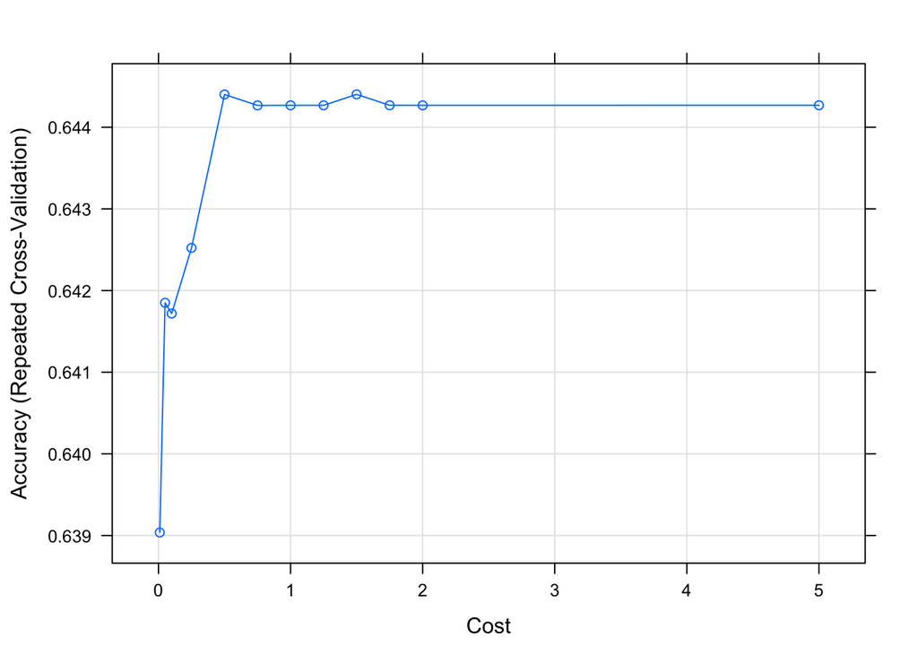

```r
plot(svm_Linear_Grid)
```

Sebagaimana yang telah dijelaskan dilangkah sebelumnya, disini ditampilkan visualisasi relasi nilai C (cost) dengan akurasinya yang paling tinggi adalah pada nilai cost final yang berada di puncak tertinggi pada grafik.

```r
test_pred_grid <- predict(svm_Linear_Grid, newdata = testing)
```

Dengan hasil model sebelumnya dan dengan data testing, kami melakukan prediksi dan disimpan dalam variabel test_pred_grid.

```r
test_pred_grid
```

```
##   [1] Ya    Tidak Ya    Ya    Tidak Tidak Tidak Ya    Ya    Ya    Tidak Tidak
##  [13] Tidak Ya    Tidak Tidak Tidak Ya    Ya    Tidak Tidak Tidak Ya    Ya
##  [25] Ya    Tidak Tidak Tidak Ya    Ya    Ya    Ya    Tidak Tidak Ya    Tidak
##  [37] Ya    Ya    Ya    Tidak Tidak Tidak Tidak Tidak Tidak Tidak Ya    Ya
##  [49] Ya    Ya    Ya    Ya    Ya    Ya    Tidak Tidak Tidak Ya    Ya    Ya
##  [61] Tidak Tidak Tidak Tidak Tidak Tidak Tidak Tidak Tidak Ya    Ya    Tidak
##  [73] Tidak Tidak Tidak Tidak Tidak Tidak Tidak Ya    Ya    Ya    Ya    Tidak
##  [85] Ya    Tidak Ya    Ya    Ya    Ya    Tidak Ya    Ya    Tidak Tidak Ya
##  [97] Tidak Tidak Ya    Ya    Ya    Ya    Ya    Ya    Ya    Ya    Ya    Ya
## [109] Tidak Tidak Ya    Ya    Ya    Tidak Ya    Ya    Ya    Tidak Ya    Ya
## [121] Ya    Tidak Tidak Ya    Ya    Ya    Ya    Ya    Ya    Ya    Ya    Ya
## [133] Ya    Ya    Ya    Ya    Ya    Ya    Ya    Ya    Ya    Ya    Ya    Ya
## [145] Ya    Ya    Ya    Ya    Ya    Ya    Ya    Ya    Ya    Tidak Tidak Ya
## [157] Ya    Ya    Ya    Ya    Ya    Ya    Ya    Tidak Ya    Ya    Ya    Ya
## [169] Ya    Ya    Ya    Ya    Ya    Tidak Ya    Ya    Ya    Ya    Tidak Ya
```

[output cut: 38 more lines]

```r
confusionMatrix(table(test_pred_grid, testing$tepat))
```

```
## Confusion Matrix and Statistics
##
##
## test_pred_grid Tidak  Ya
##          Tidak   144  73
##          Ya      166 237
##
##                Accuracy : 0.6145
##                  95% CI : (0.5749, 0.653)
##     No Information Rate : 0.5
##     P-Value [Acc > NIR] : 6.472e-09
##
##                   Kappa : 0.229
##
##  Mcnemar's Test P-Value : 2.665e-09
##
##             Sensitivity : 0.4645
##             Specificity : 0.7645
##          Pos Pred Value : 0.6636
##          Neg Pred Value : 0.5881
##              Prevalence : 0.5000
##          Detection Rate : 0.2323
##    Detection Prevalence : 0.3500
##       Balanced Accuracy : 0.6145
##
##        'Positive' Class : Tidak
##
```